# Demographic, Lifestyle, and Clinical Correlates of Hypertension

A Survey-Weighted Cross-Sectional Analysis of NHANES 2017-March 2020

Your Name

2026-09-28

# 1 Research question

> What demographic, lifestyle, and clinical factors are associated with hypertension among U.S. adults, and does dietary sodium intake add explanatory value beyond those core risk factors?

This is an observational, cross-sectional analysis: it can establish association, not causation, and that distinction is maintained throughout rather than only mentioned in the limitations.

# 2 1. Data acquisition

```r
# Downloads on first run (needs internet access to wwwn.cdc.gov) and caches
# to data/raw/*.rds afterward, so re-knitting doesn't re-download. Delete a
# cached .rds (or pass force_refresh = TRUE) to pull a fresh copy.
raw <- load_all_nhanes_tables(raw_dir = file.path(analysis_dir, "data", "raw"))

purrr::iwalk(raw, ~ cat(sprintf("%-10s %5d rows, %3d columns\n", .y, nrow(.x), ncol(.x))))
```

```
## P_DEMO     15560 rows,  29 columns
## P_BPXO     11656 rows,  12 columns
## P_BPQ      10195 rows,  11 columns
## P_BMX      14300 rows,  22 columns
## P_PAQ       9693 rows,  17 columns
## P_SMQ      11137 rows,  16 columns
## P_ALQ       8965 rows,  10 columns
## P_DIQ      14986 rows,  28 columns
## P_TCHOL    12198 rows,   3 columns
## P_DR1TOT   14300 rows, 168 columns
```

Ten NHANES tables were pulled, spanning every data type NHANES is known for: demographics + sample weights (`P_DEMO`), a physical exam (`P_BPXO` blood pressure, `P_BMX` body measures), a laboratory measurement (`P_TCHOL` total cholesterol), interview questionnaires (`P_BPQ`, `P_PAQ`, `P_SMQ`, `P_ALQ`, `P_DIQ`), and a 24-hour dietary recall (`P_DR1TOT`).

# 3 2. Data cleaning, merging & derived variables

```r
# All tables key on SEQN (respondent sequence number). We merge everything
# onto P_DEMO (which is where the sample weights and design variables live)
# with left joins, so every DEMO respondent is retained even if a given
# questionnaire module has item-level nonresponse for them -- that
# nonresponse becomes explicit NA rather than a silently dropped row.
merged <- raw$P_DEMO |>
  left_join(raw$P_BPXO, by = "SEQN") |>
  left_join(raw$P_BPQ, by = "SEQN") |>
  left_join(raw$P_BMX, by = "SEQN") |>
  left_join(raw$P_PAQ, by = "SEQN") |>
  left_join(raw$P_SMQ, by = "SEQN") |>
  left_join(raw$P_ALQ, by = "SEQN") |>
  left_join(raw$P_DIQ, by = "SEQN") |>
  left_join(raw$P_TCHOL, by = "SEQN") |>
  left_join(raw$P_DR1TOT, by = "SEQN")

nrow(raw$P_DEMO); nrow(merged)  # should match -- confirms a clean 1:1 merge
```

```
## [1] 15560
```

```
## [1] 15560
```

```r
analytic <- merged |>
  mutate(
    age = RIDAGEYR,
    sex = factor(RIAGENDR, levels = c(1, 2), labels = c("Male", "Female")),
    race_ethnicity = factor(RIDRETH3,
      levels = c(3, 4, 1, 2, 6, 7),
      labels = c("Non-Hispanic White", "Non-Hispanic Black", "Mexican American",
                 "Other Hispanic", "Non-Hispanic Asian", "Other/Multi-racial")),
    education = factor(DMDEDUC2,
      levels = 1:5,
      labels = c("Less than 9th grade", "9-11th grade", "High school grad/GED",
                 "Some college/AA", "College graduate+")),
    income_poverty_ratio = INDFMPIR,

    mean_sbp = mean_oscillometric_bp(BPXOSY1, BPXOSY2, BPXOSY3),
    mean_dbp = mean_oscillometric_bp(BPXODI1, BPXODI2, BPXODI3),
    on_bp_meds = BPQ050A == 1,

    bmi = BMXBMI,
    bmi_cat = classify_bmi(BMXBMI),
    smoking = classify_smoking(SMQ020, SMQ040),
    alcohol = classify_alcohol(ALQ121, ALQ130, sex),
    diabetes = factor(dplyr::case_when(DIQ010 == 1 ~ "Yes", DIQ010 == 2 ~ "No",
                                        TRUE ~ NA_character_),
                       levels = c("No", "Yes")),
    total_cholesterol = LBXTC,

    pa_moderate_equiv_min = compute_pa_met_minutes(pick(PAQ605, PAQ610, PAD615,
                                                          PAQ620, PAQ625, PAD630,
                                                          PAQ635, PAQ640, PAD645,
                                                          PAQ650, PAQ655, PAD660,
                                                          PAQ665, PAQ670, PAD675)),
    pa_any_domain_answered = if_any(c(PAQ605, PAQ620, PAQ635, PAQ650, PAQ665), ~ .x %in% c(1, 2)),
    meets_pa_guidelines = meets_pa_guidelines(pa_moderate_equiv_min, pa_any_domain_answered),

    dietary_sodium_mg = DR1TSODI,
    dietary_kcal = DR1TKCAL,
    dietary_recall_reliable = DR1DRSTZ == 1,

    age_group = cut(age, breaks = seq(18, 80, by = 10), right = FALSE)
  )

hyp <- define_hypertension(analytic$mean_sbp, analytic$mean_dbp, analytic$on_bp_meds)
analytic$hypertension <- factor(hyp$aha2017, levels = c(FALSE, TRUE), labels = c("No", "Yes"))
analytic$hypertension_jnc7 <- factor(hyp$jnc7, levels = c(FALSE, TRUE), labels = c("No", "Yes"))

# Plain 0/1 numeric copies of the outcome, for use inside svyby()/svymean()
# formulas. svyby() names its output column after the deparsed formula
# expression, so a formula like ~I(hypertension == "Yes") produces a
# sanitized, hard-to-predict column name (make.names() mangles the quotes
# and parens) rather than literally "I(hypertension == \"Yes\")" -- fragile
# to reference afterward in ggplot. A pre-derived numeric column has a
# fixed, known name instead.
analytic$hypertension_num <- as.numeric(analytic$hypertension == "Yes")
analytic$hypertension_jnc7_num <- as.numeric(analytic$hypertension_jnc7 == "Yes")

glimpse(analytic |> select(SEQN, age, sex, hypertension, mean_sbp, mean_dbp,
                            bmi_cat, smoking, alcohol, diabetes))
```

```
## Rows: 15,560
## Columns: 10
## $ SEQN         <dbl> 109263, 109264, 109265, 109266, 109267, 109268, 109269, 1…
## $ age          <dbl> 2, 13, 2, 29, 21, 18, 2, 11, 49, 0, 36, 68, 6, 0, 12, 6, …
## $ sex          <fct> Male, Female, Male, Female, Female, Female, Male, Female,…
## $ hypertension <fct> NA, No, NA, No, NA, NA, NA, No, No, NA, No, Yes, NA, NA, …
## $ mean_sbp     <dbl> NA, 107.5, NA, 99.0, NA, NA, NA, 125.5, 109.5, NA, 112.5,…
## $ mean_dbp     <dbl> NA, 67.0, NA, 53.5, NA, NA, NA, 73.5, 68.0, NA, 67.0, 70.…
## $ bmi_cat      <fct> NA, Underweight, Underweight, Obese, NA, NA, NA, Obese, O…
## $ smoking      <fct> NA, NA, NA, Never, Never, Never, NA, NA, Current, NA, Cur…
## $ alcohol      <fct> NA, NA, NA, Moderate, NA, NA, NA, NA, None (past year), N…
## $ diabetes     <fct> No, No, No, No, No, No, No, No, No, NA, No, Yes, Yes, NA,…
```

**Analytic population.** NHANES exam-based blood pressure is only collected from age 8+, but the self-report modules used here (`BPQ`, `SMQ`, `ALQ`, `DIQ`) are adult-only (18+). We restrict to adults who both completed the interview AND the MEC exam (`RIDSTATR == 2`) – domain restriction happens on the survey **design**, not the raw data.frame, in Section 4, so variance estimation stays correct.

```r
analytic |>
  filter(RIDSTATR == 2, age >= 18) |>
  count(has_bp = !is.na(hypertension)) |>
  mutate(pct = round(100 * n / sum(n), 1))
```

```
##   has_bp    n  pct
## 1  FALSE  672  7.5
## 2   TRUE 8293 92.5
```

# 4 3. Missingness

```r
analytic_adult <- analytic |> filter(RIDSTATR == 2, age >= 18)

vars_of_interest <- c("hypertension", "bmi_cat", "smoking", "alcohol", "diabetes",
                       "total_cholesterol", "meets_pa_guidelines", "education",
                       "income_poverty_ratio", "race_ethnicity")
analytic_adult |> select(all_of(vars_of_interest)) |> naniar::miss_var_summary()
```

```
## # A tibble: 10 × 3
##    variable             n_miss pct_miss
##    <chr>                 <int>    <num>
##  1 alcohol                1468  16.4
##  2 income_poverty_ratio   1260  14.1
##  3 hypertension            672   7.50
##  4 total_cholesterol       667   7.44
##  5 education               434   4.84
##  6 diabetes                256   2.86
##  7 bmi_cat                 175   1.95
##  8 smoking                   4   0.0446
##  9 meets_pa_guidelines       0   0
## 10 race_ethnicity            0   0
```

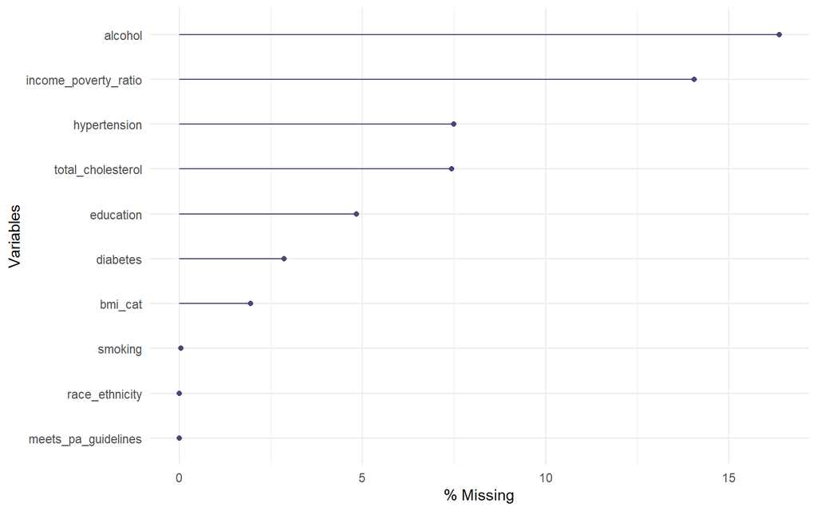

```r
analytic_adult |> select(all_of(vars_of_interest)) |> naniar::gg_miss_var(show_pct = TRUE)
```

# 5 4. Survey design

```r
# CRITICAL: build the design on the FULL sample first, using every DEMO
# respondent, and only THEN subset() down to the analytic domain (adults,
# MEC-examined, valid hypertension classification). Filtering the
# data.frame BEFORE creating the design would silently throw away the
# correct PSU/strata bookkeeping for variance estimation -- subsetting the
# design object afterward is what keeps standard errors correct. This is
# one of the most common real-world NHANES analysis mistakes.
full_design <- svydesign(
  ids = ~SDMVPSU,
  strata = ~SDMVSTRA,
  weights = ~WTMECPRP,
  nest = TRUE,
  data = analytic
)

hyp_design <- subset(full_design, RIDSTATR == 2 & age >= 18 & !is.na(hypertension))

hyp_design
```

```
## Stratified 1 - level Cluster Sampling design (with replacement)
## With (49) clusters.
## subset(full_design, RIDSTATR == 2 & age >= 18 & !is.na(hypertension))
```

```r
# Diagnostic breakdown of each domain-filter condition individually, so a
# 0-row (or unexpectedly small) analytic domain fails HERE with a clear
# reason, instead of surfacing three chunks later as an opaque gtsummary
# "0 rows" error with no indication of which condition is the culprit.
# NOTE: these diagnostics use message(), not cat()/print(). cat()/print()
# output only lands in the KNITTED DOCUMENT, which never gets produced
# because this same chunk goes on to call stop() -- so with cat()/print()
# the diagnostic output would be invisible and only the final error would
# show. message() writes to stderr and streams into RStudio's "Render"
# console/build log in real time, so it survives even though the chunk
# goes on to fail.
message("RIDSTATR value counts (2 = interviewed AND MEC-examined; download_data.R ",
        "forces translated = FALSE so this stays a plain numeric code -- see below):")
message(paste(capture.output(table(analytic$RIDSTATR, useNA = "ifany")), collapse = "\n"))

message("\nclass/str of RIDSTATR (should be numeric/integer, not character/factor -- ",
        "a factor here would mean translated = FALSE isn't taking effect, e.g. a stale cached .rds):")
message(paste(capture.output(str(analytic$RIDSTATR)), collapse = "\n"))

message("\nRows satisfying RIDSTATR == 2: ",
    sum(analytic$RIDSTATR == 2, na.rm = TRUE))
message("Rows satisfying age >= 18:                                  ", sum(analytic$age >= 18, na.rm = TRUE))
message("Rows with non-missing mean_sbp or mean_dbp:                 ",
    sum(!is.na(analytic$mean_sbp) | !is.na(analytic$mean_dbp)))
message("Rows with non-missing hypertension:                         ", sum(!is.na(analytic$hypertension)))
message("Rows satisfying ALL THREE domain conditions:                ",
    sum(analytic$RIDSTATR == 2 & analytic$age >= 18 & !is.na(analytic$hypertension), na.rm = TRUE))

if (nrow(hyp_design) == 0) {
  stop(
    "hyp_design has 0 rows -- the domain filter matched nothing. Check the ",
    "counts printed just above to see which condition is zeroing this out ",
    "(a common cause is RIDSTATR being a labeled factor rather than a plain ",
    "numeric code -- see the str() output above), fix the upstream cause, ",
    "then re-knit rather than proceeding into Table 1/modeling on an empty design."
  )
}
```

```r
cat("Unweighted adults in analytic domain:", nrow(hyp_design), "\n")
```

```
## Unweighted adults in analytic domain: 8293
```

```r
cat("Weighted population represented:", scales::comma(sum(weights(hyp_design))), "\n")
```

```
## Weighted population represented: 231,774,165
```

# 6 5. Descriptive epidemiology (Table 1)

```r
# tbl_svysummary() takes a base `survey` package design object directly --
# no srvyr conversion needed -- and its own `include=` argument selects
# variables, so we don't need to pipe the design through dplyr::select()
# first (a survey.design object isn't a data.frame, and its handling under
# dplyr verbs vs. gtsummary's built-in argument isn't worth the risk when
# the built-in argument does the same job directly).
hyp_design |>
  tbl_svysummary(
    by = hypertension,
    include = c(age, sex, race_ethnicity, education, income_poverty_ratio,
                bmi_cat, smoking, alcohol, diabetes, total_cholesterol,
                meets_pa_guidelines),
    statistic = list(all_continuous() ~ "{mean} ({sd})",
                      all_categorical() ~ "{n} ({p}%)"),
    missing = "no"
  ) |>
  add_p() |>
  add_overall() |>
  modify_caption("**Table 1. Weighted characteristics of U.S. adults, by hypertension status**") |>
  modify_header(label = "**Characteristic**")
```

**Table 1. Weighted characteristics of U.S. adults, by hypertension status**

| **Characteristic** | **Overall** N = 231,774,165<sup>1</sup> | **No** N = 118,798,473<sup>1</sup> | **Yes** N = 112,975,692<sup>1</sup> | **p-value**<sup>2</sup> |
| --- | --- | --- | --- | --- |
| age | 48 (18) | 40 (16) | 56 (16) | <0.001 |
| sex |  |  |  | 0.001 |
| Male | 112,725,754 (49%) | 54,456,820 (46%) | 58,268,934 (52%) |  |
| Female | 119,048,411 (51%) | 64,341,652 (54%) | 54,706,759 (48%) |  |
| race_ethnicity |  |  |  | <0.001 |
| Non-Hispanic White | 146,944,317 (63%) | 75,074,402 (63%) | 71,869,915 (64%) |  |
| Non-Hispanic Black | 26,412,175 (11%) | 10,943,882 (9.2%) | 15,468,294 (14%) |  |
| Mexican American | 18,724,667 (8.1%) | 11,721,454 (9.9%) | 7,003,212 (6.2%) |  |
| Other Hispanic | 17,268,591 (7.5%) | 9,564,482 (8.1%) | 7,704,109 (6.8%) |  |
| Non-Hispanic Asian | 12,936,574 (5.6%) | 6,955,490 (5.9%) | 5,981,085 (5.3%) |  |
| Other/Multi-racial | 9,487,841 (4.1%) | 4,538,763 (3.8%) | 4,949,078 (4.4%) |  |
| education |  |  |  | <0.001 |
| Less than 9th grade | 7,698,677 (3.4%) | 3,155,020 (2.8%) | 4,543,657 (4.0%) |  |
| 9-11th grade | 15,856,093 (7.1%) | 6,733,592 (6.0%) | 9,122,501 (8.1%) |  |
| High school grad/GED | 61,409,806 (27%) | 27,441,037 (24%) | 33,968,769 (30%) |  |
| Some college/AA | 68,848,873 (31%) | 33,284,700 (30%) | 35,564,173 (32%) |  |
| College graduate+ | 71,068,870 (32%) | 41,853,273 (37%) | 29,215,597 (26%) |  |
| income_poverty_ratio | 3.12 (1.64) | 3.12 (1.68) | 3.11 (1.61) | 0.8 |
| bmi_cat |  |  |  | <0.001 |
| Normal | 58,198,288 (25%) | 40,038,413 (34%) | 18,159,875 (16%) |  |
| Underweight | 3,331,577 (1.5%) | 2,607,346 (2.2%) | 724,231 (0.7%) |  |
| Overweight | 71,990,945 (31%) | 38,145,597 (32%) | 33,845,348 (30%) |  |
| Obese | 96,043,908 (42%) | 37,541,693 (32%) | 58,502,215 (53%) |  |
| smoking |  |  |  | <0.001 |
| Never | 134,652,535 (58%) | 74,786,580 (63%) | 59,865,955 (53%) |  |
| Former | 58,784,899 (25%) | 24,714,343 (21%) | 34,070,556 (30%) |  |
| Current | 38,273,056 (17%) | 19,280,126 (16%) | 18,992,930 (17%) |  |
| alcohol |  |  |  | <0.001 |
| None (past year) | 35,927,032 (17%) | 13,916,731 (13%) | 22,010,301 (22%) |  |
| Moderate | 155,451,690 (75%) | 86,587,322 (81%) | 68,864,367 (68%) |  |
| Heavy | 16,591,136 (8.0%) | 6,913,581 (6.4%) | 9,677,554 (9.6%) |  |
| diabetes | 27,164,692 (12%) | 5,034,621 (4.3%) | 22,130,071 (20%) | <0.001 |
| total_cholesterol | 187 (41) | 183 (40) | 190 (42) | <0.001 |
| meets_pa_guidelines | 158,033,583 (68%) | 89,260,047 (75%) | 68,773,536 (61%) | <0.001 |

<sup>1</sup> Mean (SD); n (%)  
<sup>2</sup> Design-based KruskalWallis test; Pearson’s X^2: Rao & Scott adjustment

```r
svymean(~hypertension, hyp_design, na.rm = TRUE)
```

```
##                    mean     SE
## hypertensionNo  0.51256 0.0123
## hypertensionYes 0.48744 0.0123
```

```r
svyby(~hypertension_num, ~sex, hyp_design, svymean, na.rm = TRUE)
```

```
##           sex hypertension_num         se
## Male     Male        0.5169088 0.01554338
## Female Female        0.4595337 0.01360890
```

```r
svyby(~hypertension_num, ~race_ethnicity, hyp_design, svymean, na.rm = TRUE)
```

```
##                        race_ethnicity hypertension_num         se
## Non-Hispanic White Non-Hispanic White        0.4890963 0.01964060
## Non-Hispanic Black Non-Hispanic Black        0.5856501 0.01582209
## Mexican American     Mexican American        0.3740100 0.01515499
## Other Hispanic         Other Hispanic        0.4461342 0.02080486
## Non-Hispanic Asian Non-Hispanic Asian        0.4623391 0.01446351
## Other/Multi-racial Other/Multi-racial        0.5216232 0.03932668
```

# 7 6. Survey-weighted exploratory analysis

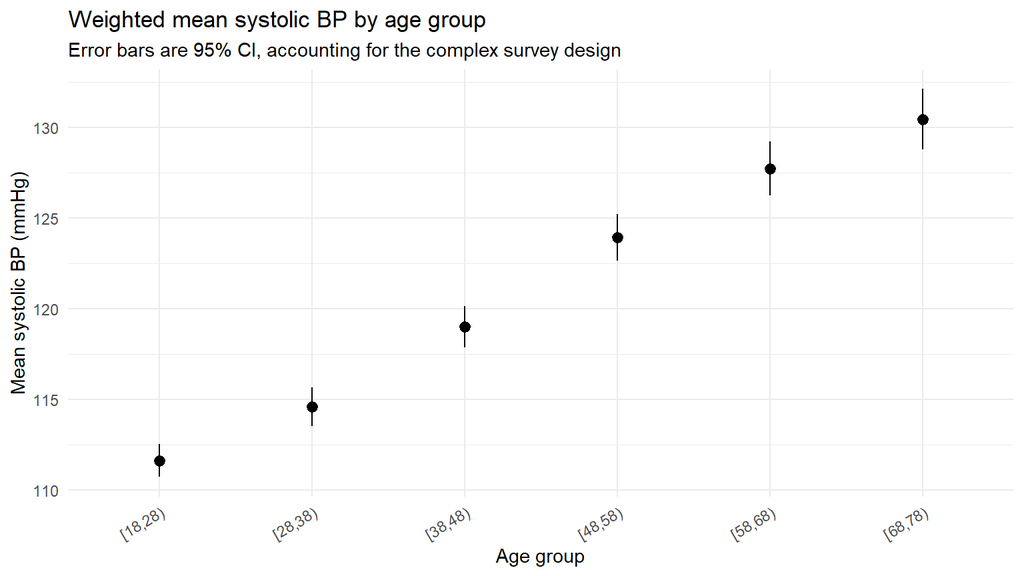

```r
age_bp <- svyby(~mean_sbp, ~age_group, hyp_design, svymean, na.rm = TRUE)

ggplot(age_bp, aes(x = age_group, y = mean_sbp)) +
  geom_pointrange(aes(ymin = mean_sbp - 1.96 * se, ymax = mean_sbp + 1.96 * se)) +
  labs(title = "Weighted mean systolic BP by age group",
       subtitle = "Error bars are 95% CI, accounting for the complex survey design",
       x = "Age group", y = "Mean systolic BP (mmHg)") +
  theme_minimal() +
  theme(axis.text.x = element_text(angle = 30, hjust = 1))
```

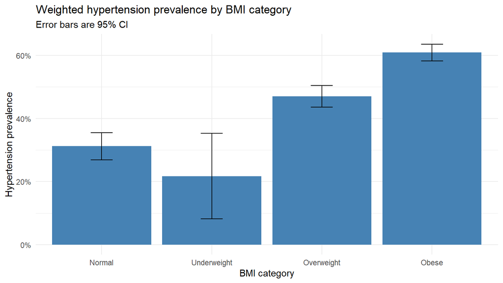

```r
bmi_hyp <- svyby(~hypertension_num, ~bmi_cat, hyp_design, svymean, na.rm = TRUE)

ggplot(bmi_hyp, aes(x = bmi_cat, y = hypertension_num)) +
  geom_col(fill = "steelblue") +
  geom_errorbar(aes(ymin = hypertension_num - 1.96 * se,
                     ymax = hypertension_num + 1.96 * se), width = 0.2) +
  scale_y_continuous(labels = scales::percent) +
  labs(title = "Weighted hypertension prevalence by BMI category",
       subtitle = "Error bars are 95% CI", x = "BMI category", y = "Hypertension prevalence") +
  theme_minimal()
```

A clear gradient by BMI category, and a rising mean SBP by age decade, are exactly what the epidemiological literature predicts – a useful sanity check before moving to multivariable modeling.

# 8 7. Modeling

## 8.1 7.1 Crude (unadjusted) associations

```r
crude_vars <- c("age", "sex", "race_ethnicity", "education", "income_poverty_ratio",
                 "bmi_cat", "smoking", "alcohol", "diabetes", "total_cholesterol",
                 "meets_pa_guidelines")

crude_results <- purrr::map_dfr(crude_vars, function(v) {
  f <- as.formula(paste("hypertension == 'Yes' ~", v))
  m <- svyglm(f, design = hyp_design, family = quasibinomial())
  svyglm_or_table(m) |> mutate(predictor = v, .before = 1)
})

crude_results |> filter(term != "(Intercept)") |>
  select(predictor, term, or, or_low, or_high, p_value)
```

```
## # A tibble: 22 × 6
##    predictor      term                                or or_low or_high  p_value
##    <chr>          <chr>                            <dbl>  <dbl>   <dbl>    <dbl>
##  1 age            age                              1.06   1.06    1.07  1.65e-19
##  2 sex            sexFemale                        0.795  0.698   0.905 1.29e- 3
##  3 race_ethnicity race_ethnicityNon-Hispanic Black 1.48   1.20    1.82  9.46e- 4
##  4 race_ethnicity race_ethnicityMexican American   0.624  0.496   0.786 3.79e- 4
##  5 race_ethnicity race_ethnicityOther Hispanic     0.841  0.659   1.07  1.55e- 1
##  6 race_ethnicity race_ethnicityNon-Hispanic Asian 0.898  0.748   1.08  2.37e- 1
##  7 race_ethnicity race_ethnicityOther/Multi-racial 1.14   0.784   1.66  4.76e- 1
##  8 education      education9-11th grade            0.941  0.699   1.27  6.73e- 1
##  9 education      educationHigh school grad/GED    0.860  0.663   1.12  2.40e- 1
## 10 education      educationSome college/AA         0.742  0.606   0.908 5.77e- 3
## # ℹ 12 more rows
```

## 8.2 7.2 Adjusted (primary) model

```r
m_adjusted <- svyglm(
  hypertension == "Yes" ~ age + sex + race_ethnicity + education +
    income_poverty_ratio + bmi_cat + smoking + alcohol + diabetes +
    total_cholesterol + meets_pa_guidelines,
  design = hyp_design, family = quasibinomial()
)

summary(m_adjusted)
```

```
##
## Call:
## svyglm(formula = hypertension == "Yes" ~ age + sex + race_ethnicity +
##     education + income_poverty_ratio + bmi_cat + smoking + alcohol +
##     diabetes + total_cholesterol + meets_pa_guidelines, design = hyp_design,
##     family = quasibinomial())
##
## Survey design:
## subset(full_design, RIDSTATR == 2 & age >= 18 & !is.na(hypertension))
##
## Coefficients:
##                                    Estimate Std. Error t value Pr(>|t|)
## (Intercept)                      -4.1311951  0.4100569 -10.075 0.002082 **
## age                               0.0562128  0.0036156  15.547 0.000578 ***
## sexFemale                        -0.4436923  0.1426627  -3.110 0.052878 .
## race_ethnicityNon-Hispanic Black  0.7341897  0.1541404   4.763 0.017573 *
## race_ethnicityMexican American   -0.2451584  0.1539112  -1.593 0.209440
## race_ethnicityOther Hispanic      0.0279377  0.1813436   0.154 0.887343
## race_ethnicityNon-Hispanic Asian  0.6053798  0.1646461   3.677 0.034833 *
## race_ethnicityOther/Multi-racial  0.1219052  0.1970175   0.619 0.579885
## education9-11th grade             0.1701846  0.1782458   0.955 0.410129
## educationHigh school grad/GED     0.2325878  0.1604198   1.450 0.242968
## educationSome college/AA          0.1384634  0.1344184   1.030 0.378745
## educationCollege graduate+       -0.2547531  0.1533699  -1.661 0.195291
## income_poverty_ratio              0.0186635  0.0255688   0.730 0.518263
## bmi_catUnderweight               -0.3033472  0.7310577  -0.415 0.706073
## bmi_catOverweight                 0.4238134  0.1592012   2.662 0.076200 .
## bmi_catObese                      1.1797252  0.1105053  10.676 0.001757 **
## smokingFormer                     0.0630623  0.0931140   0.677 0.546792
## smokingCurrent                    0.1752199  0.1268853   1.381 0.261191
## alcoholModerate                   0.1136025  0.1658546   0.685 0.542550
## alcoholHeavy                      0.7609240  0.1954881   3.892 0.030072 *
## diabetesYes                       0.9006206  0.1645351   5.474 0.011988 *
## total_cholesterol                 0.0033935  0.0009575   3.544 0.038247 *
## meets_pa_guidelinesTRUE          -0.3064129  0.0939075  -3.263 0.047028 *
## ---
## Signif. codes:  0 '***' 0.001 '**' 0.01 '*' 0.05 '.' 0.1 ' ' 1
##
## (Dispersion parameter for quasibinomial family taken to be 1.106124)
##
## Number of Fisher Scoring iterations: 4
```

```r
adj_or <- svyglm_or_table(m_adjusted) |> filter(term != "(Intercept)")
adj_or
```

```
## # A tibble: 22 × 7
##    term                 estimate_log_odds std_error p_value    or or_low or_high
##    <chr>                            <dbl>     <dbl>   <dbl> <dbl>  <dbl>   <dbl>
##  1 age                             0.0562   0.00362 5.78e-4 1.06   1.05     1.07
##  2 sexFemale                      -0.444    0.143   5.29e-2 0.642  0.408    1.01
##  3 race_ethnicityNon-H…            0.734    0.154   1.76e-2 2.08   1.28     3.40
##  4 race_ethnicityMexic…           -0.245    0.154   2.09e-1 0.783  0.480    1.28
##  5 race_ethnicityOther…            0.0279   0.181   8.87e-1 1.03   0.577    1.83
##  6 race_ethnicityNon-H…            0.605    0.165   3.48e-2 1.83   1.08     3.09
##  7 race_ethnicityOther…            0.122    0.197   5.80e-1 1.13   0.603    2.11
##  8 education9-11th gra…            0.170    0.178   4.10e-1 1.19   0.672    2.09
##  9 educationHigh schoo…            0.233    0.160   2.43e-1 1.26   0.757    2.10
## 10 educationSome colle…            0.138    0.134   3.79e-1 1.15   0.749    1.76
## # ℹ 12 more rows
```

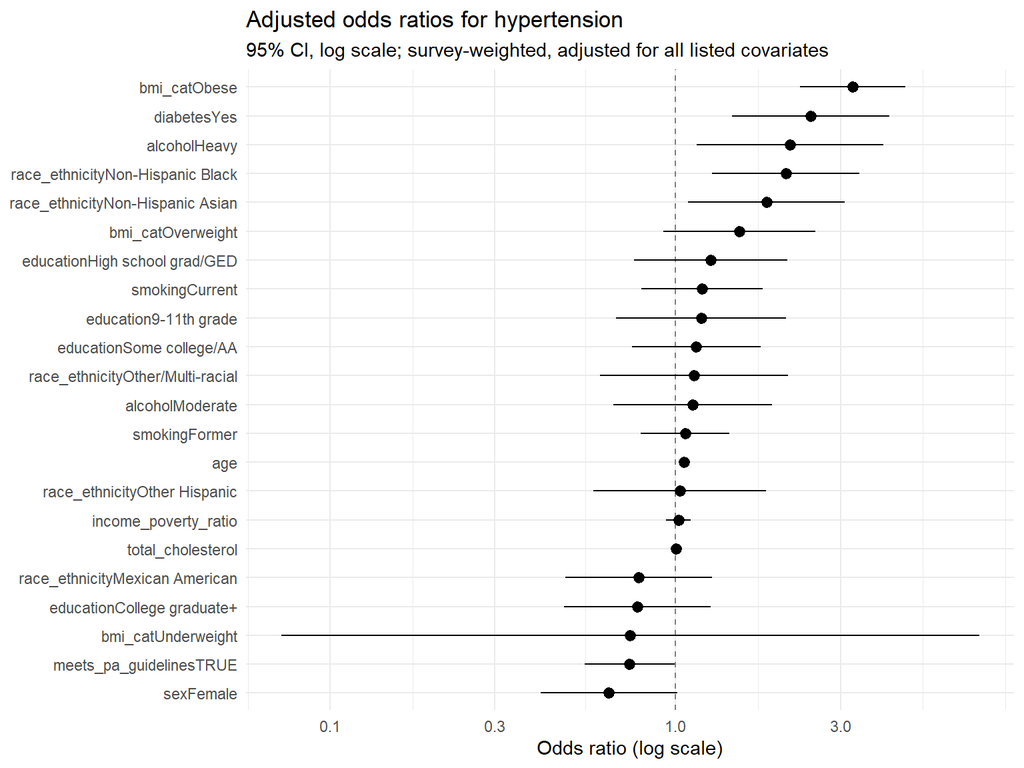

```r
adj_or |>
  mutate(term = fct_reorder(term, or)) |>
  ggplot(aes(x = or, y = term)) +
  geom_vline(xintercept = 1, linetype = "dashed", color = "grey50") +
  geom_pointrange(aes(xmin = or_low, xmax = or_high)) +
  scale_x_log10() +
  labs(title = "Adjusted odds ratios for hypertension",
       subtitle = "95% CI, log scale; survey-weighted, adjusted for all listed covariates",
       x = "Odds ratio (log scale)", y = NULL) +
  theme_minimal()
```

# 9 8. Model diagnostics

## 9.1 8.1 Multicollinearity

```r
tryCatch({
  car::vif(m_adjusted)
}, error = function(e) {
  message("car::vif() did not run cleanly on this svyglm object (", conditionMessage(e), ")")
})
```

```
##                              GVIF Df GVIF^(1/(2*Df))
## age                     64.455923  1        8.028445
## sex                     21.796758  1        4.668700
## race_ethnicity       30982.178029  5        2.812621
## education             9431.338913  4        3.139219
## income_poverty_ratio    16.212012  1        4.026414
## bmi_cat               2248.599300  3        3.619529
## smoking                 72.295452  2        2.915934
## alcohol                154.367913  2        3.524839
## diabetes                 3.722292  1        1.929324
## total_cholesterol       16.908123  1        4.111949
## meets_pa_guidelines     13.547915  1        3.680749
```

## 9.2 8.2 Linearity of continuous predictors

```r
# svyglm doesn't support a design-consistent anova()/LRT the way lm/glm do;
# regTermTest() is the correct survey-adjusted Wald test for whether adding
# flexibility (here, a spline) to a term improves fit -- the survey-design
# analogue of the ML-refit LRT used for ordinary GLMs.
#
# regTermTest() needs a formula naming the EXACT term label R assigned in
# terms(m_adjusted_spline) -- rather than hand-typing that (its deparsed
# text, e.g. spacing around commas, isn't worth relying on sight-unseen),
# we pull the label the model itself assigned and build the formula from
# that, so this is correct regardless of exact deparse formatting.
m_adjusted_spline <- update(m_adjusted, . ~ . - age + splines::ns(age, df = 3))

spline_term <- grep("ns\\(age", attr(terms(m_adjusted_spline), "term.labels"), value = TRUE)
stopifnot(length(spline_term) == 1)
regTermTest(m_adjusted_spline, as.formula(paste("~", spline_term)))
```

```
## Wald test for splines::ns(age, df = 3)
##  in svyglm(formula = hypertension == "Yes" ~ sex + race_ethnicity +
##     education + income_poverty_ratio + bmi_cat + smoking + alcohol +
##     diabetes + total_cholesterol + meets_pa_guidelines + splines::ns(age,
##     df = 3), design = hyp_design, family = quasibinomial())
## F =  87.35734  on  3  and  1  df: p= 0.078451
```

```r
# BMI and total cholesterol enter the model as a category and a linear term
# respectively; bmi_cat already absorbs nonlinearity by construction. A
# parallel spline check for total_cholesterol is the natural next line here
# if the linear term's significance or direction looks surprising once run.
```

## 9.3 8.3 Calibration

```r
# predict.svyglm does NOT respect na.action = na.pass the way predict.glm
# does -- it still silently DROPS rows with any missing predictor rather
# than returning NA for them, which is why pred_probs kept coming back
# shorter than nrow(hyp_design) (5471 vs 8293) even after passing that
# argument. Rather than fight predict()'s internal NA handling, we sidestep
# it: restrict the calibration domain to exactly the complete cases the
# adjusted model was actually fit on (the same predictors, the same rows),
# so predict() and the design are guaranteed to line up -- and this is also
# the methodologically correct comparison set, since a calibration check
# should assess the model against the sample it was estimated from, not a
# broader domain it never saw.
model_vars <- c("hypertension", "age", "sex", "race_ethnicity", "education",
                "income_poverty_ratio", "bmi_cat", "smoking", "alcohol",
                "diabetes", "total_cholesterol", "meets_pa_guidelines")

hyp_design_complete <- subset(
  hyp_design,
  complete.cases(hyp_design$variables[, model_vars])
)
analytic_domain <- hyp_design_complete$variables

pred_probs <- predict(m_adjusted, newdata = analytic_domain, type = "response")

calib <- weighted_calibration_table(
  hyp_design_complete,
  predicted = as.numeric(pred_probs),
  observed = as.numeric(analytic_domain$hypertension == "Yes")
)
calib
```

```
##    .risk_decile observed_rate       se.x predicted_rate        se.y
## 1             1     0.0820914 0.01702471      0.1029616 0.001904033
## 2             2     0.1998680 0.02593947      0.2162728 0.001383684
## 3             3     0.3086885 0.02544890      0.3236303 0.001418397
## 4             4     0.4479661 0.03102414      0.4204927 0.001523670
## 5             5     0.5861688 0.04242408      0.5239030 0.001581025
## 6             6     0.6423480 0.03710744      0.6179756 0.001680763
## 7             7     0.7073192 0.03916180      0.7007845 0.001170063
## 8             8     0.7696407 0.01894244      0.7772489 0.001143666
## 9             9     0.8041188 0.02494052      0.8516366 0.001715173
## 10           10     0.8898825 0.02255548      0.9204684 0.001384014
```

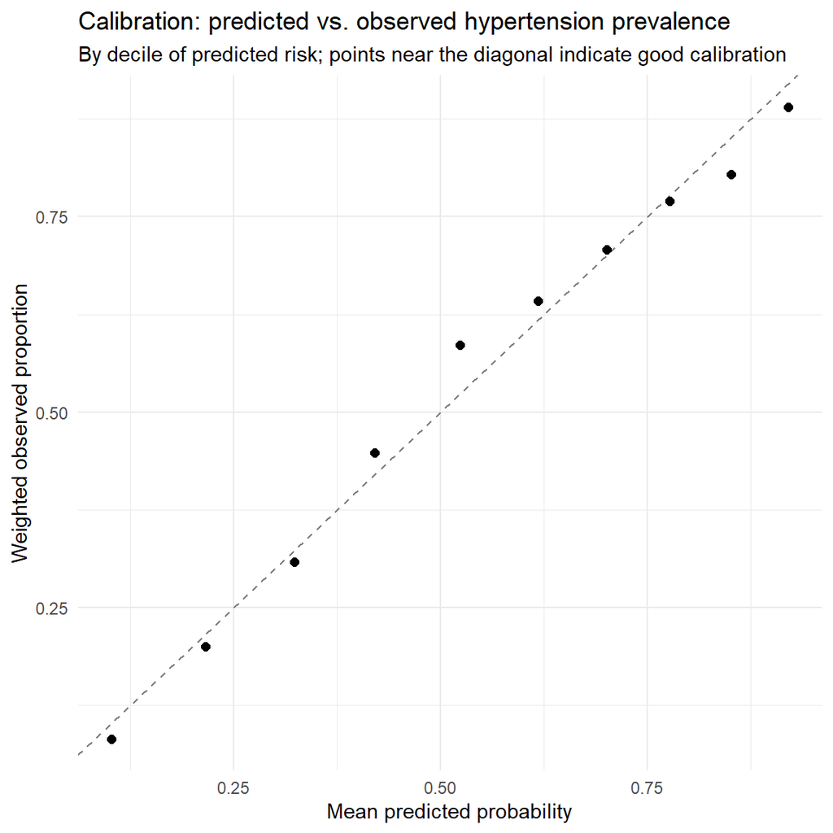

```r
ggplot(calib, aes(x = predicted_rate, y = observed_rate)) +
  geom_abline(slope = 1, intercept = 0, linetype = "dashed", color = "grey50") +
  geom_point(size = 2) +
  labs(title = "Calibration: predicted vs. observed hypertension prevalence",
       subtitle = "By decile of predicted risk; points near the diagonal indicate good calibration",
       x = "Mean predicted probability", y = "Weighted observed proportion") +
  theme_minimal()
```

# 10 9. Predicted probabilities

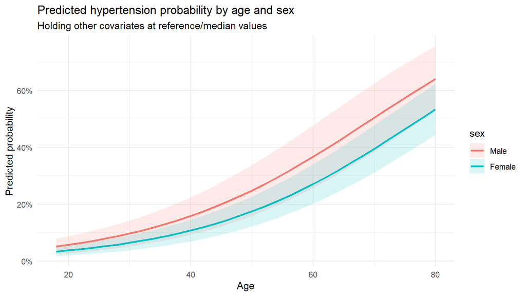

```r
pred_grid <- expand.grid(
  age = seq(18, 80, by = 2),
  sex = c("Male", "Female"),
  race_ethnicity = "Non-Hispanic White",
  education = "College graduate+",
  income_poverty_ratio = median(analytic_domain$income_poverty_ratio, na.rm = TRUE),
  bmi_cat = "Normal",
  smoking = "Never",
  alcohol = "Moderate",
  diabetes = "No",
  total_cholesterol = median(analytic_domain$total_cholesterol, na.rm = TRUE),
  meets_pa_guidelines = TRUE
)

pred <- predict(m_adjusted, newdata = pred_grid, type = "response", se.fit = TRUE)
pred_grid$fit <- as.numeric(pred)
pred_grid$se <- as.numeric(SE(pred))

ggplot(pred_grid, aes(x = age, y = fit, color = sex, fill = sex)) +
  geom_ribbon(aes(ymin = pmax(0, fit - 1.96 * se), ymax = pmin(1, fit + 1.96 * se)),
              alpha = 0.15, color = NA) +
  geom_line(linewidth = 1) +
  scale_y_continuous(labels = scales::percent) +
  labs(title = "Predicted hypertension probability by age and sex",
       subtitle = "Holding other covariates at reference/median values",
       x = "Age", y = "Predicted probability") +
  theme_minimal()
```

# 11 10. Sensitivity analyses

## 11.1 10.1 Alternative hypertension definition (JNC7 vs. ACC/AHA 2017)

```r
hyp_design_jnc7 <- subset(full_design, RIDSTATR == 2 & age >= 18 & !is.na(hypertension_jnc7))

m_jnc7 <- svyglm(
  hypertension_jnc7 == "Yes" ~ age + sex + race_ethnicity + education +
    income_poverty_ratio + bmi_cat + smoking + alcohol + diabetes +
    total_cholesterol + meets_pa_guidelines,
  design = hyp_design_jnc7, family = quasibinomial()
)

bind_rows(
  svyglm_or_table(m_adjusted) |> mutate(definition = "ACC/AHA 2017 (>=130/80)"),
  svyglm_or_table(m_jnc7) |> mutate(definition = "JNC7 (>=140/90)")
) |> filter(term != "(Intercept)") |>
  select(definition, term, or, or_low, or_high, p_value) |>
  arrange(term, definition)
```

```
## # A tibble: 44 × 6
##    definition              term                 or or_low or_high  p_value
##    <chr>                   <chr>             <dbl>  <dbl>   <dbl>    <dbl>
##  1 ACC/AHA 2017 (>=130/80) age                1.06  1.05     1.07 0.000578
##  2 JNC7 (>=140/90)         age                1.08  1.06     1.09 0.000309
##  3 ACC/AHA 2017 (>=130/80) alcoholHeavy       2.14  1.15     3.99 0.0301
##  4 JNC7 (>=140/90)         alcoholHeavy       1.61  0.805    3.24 0.116
##  5 ACC/AHA 2017 (>=130/80) alcoholModerate    1.12  0.661    1.90 0.543
##  6 JNC7 (>=140/90)         alcoholModerate    1.05  0.694    1.58 0.738
##  7 ACC/AHA 2017 (>=130/80) bmi_catObese       3.25  2.29     4.62 0.00176
##  8 JNC7 (>=140/90)         bmi_catObese       2.78  1.88     4.11 0.00368
##  9 ACC/AHA 2017 (>=130/80) bmi_catOverweight  1.53  0.921    2.54 0.0762
## 10 JNC7 (>=140/90)         bmi_catOverweight  1.57  0.962    2.58 0.0609
## # ℹ 34 more rows
```

## 11.2 10.2 Excluding those already treated (avoids “controlled-on-treatment” misclassification)

```r
# Someone on antihypertensive medication with a currently normal reading is
# coded hypertensive under the primary definition (correctly -- they have
# the condition, it's just controlled). This checks whether restricting to
# UNTREATED participants only -- a purer measure of blood pressure alone --
# changes which covariates look associated with elevated BP.
hyp_design_untreated <- subset(full_design,
  RIDSTATR == 2 & age >= 18 & !is.na(hypertension) & (is.na(on_bp_meds) | on_bp_meds == FALSE))

m_untreated <- svyglm(
  hypertension == "Yes" ~ age + sex + race_ethnicity + education +
    income_poverty_ratio + bmi_cat + smoking + alcohol + diabetes +
    total_cholesterol + meets_pa_guidelines,
  design = hyp_design_untreated, family = quasibinomial()
)
svyglm_or_table(m_untreated) |> filter(term != "(Intercept)") |>
  select(term, or, or_low, or_high, p_value)
```

```
## # A tibble: 22 × 5
##    term                                or or_low or_high p_value
##    <chr>                            <dbl>  <dbl>   <dbl>   <dbl>
##  1 age                              1.03   1.02    1.05  0.00500
##  2 sexFemale                        0.587  0.353   0.974 0.0442
##  3 race_ethnicityNon-Hispanic Black 1.88   1.03    3.42  0.0438
##  4 race_ethnicityMexican American   0.901  0.540   1.50  0.562
##  5 race_ethnicityOther Hispanic     1.02   0.500   2.07  0.945
##  6 race_ethnicityNon-Hispanic Asian 1.70   0.998   2.91  0.0504
##  7 race_ethnicityOther/Multi-racial 1.19   0.622   2.26  0.460
##  8 education9-11th grade            1.12   0.615   2.04  0.591
##  9 educationHigh school grad/GED    1.23   0.684   2.20  0.345
## 10 educationSome college/AA         1.04   0.647   1.67  0.815
## # ℹ 12 more rows
```

## 11.3 10.3 Why the survey design matters: weighted vs. naive (unweighted) model

```r
# Fits the SAME model, SAME rows, but ignoring the sample weights and
# clustering entirely -- i.e. treating NHANES like a simple random sample.
# This is deliberately the "naive" analysis this whole project is trying
# NOT to be; showing it side-by-side with the design-based model is the
# concrete demonstration of why that distinction matters, not just an
# assertion of it.
m_naive <- glm(
  hypertension == "Yes" ~ age + sex + race_ethnicity + education +
    income_poverty_ratio + bmi_cat + smoking + alcohol + diabetes +
    total_cholesterol + meets_pa_guidelines,
  data = analytic_domain, family = binomial()
)

bind_rows(
  broom::tidy(m_adjusted, conf.int = TRUE, exponentiate = TRUE) |> mutate(model = "Survey-weighted"),
  broom::tidy(m_naive, conf.int = TRUE, exponentiate = TRUE) |> mutate(model = "Naive (unweighted, i.i.d.)")
) |> filter(term != "(Intercept)") |>
  select(model, term, estimate, conf.low, conf.high, p.value) |>
  arrange(term, model)
```

```
## # A tibble: 44 × 6
##    model                      term         estimate conf.low conf.high   p.value
##    <chr>                      <chr>           <dbl>    <dbl>     <dbl>     <dbl>
##  1 Naive (unweighted, i.i.d.) age              1.06    1.06       1.07 8.26e-146
##  2 Survey-weighted            age              1.06    1.05       1.07 5.78e-  4
##  3 Naive (unweighted, i.i.d.) alcoholHeavy     2.02    1.53       2.68 8.37e-  7
##  4 Survey-weighted            alcoholHeavy     2.14    1.15       3.99 3.01e-  2
##  5 Naive (unweighted, i.i.d.) alcoholMode…     1.03    0.869      1.21 7.68e-  1
##  6 Survey-weighted            alcoholMode…     1.12    0.661      1.90 5.43e-  1
##  7 Naive (unweighted, i.i.d.) bmi_catObese     3.08    2.59       3.66 1.24e- 37
##  8 Survey-weighted            bmi_catObese     3.25    2.29       4.62 1.76e-  3
##  9 Naive (unweighted, i.i.d.) bmi_catOver…     1.56    1.31       1.86 5.87e-  7
## 10 Survey-weighted            bmi_catOver…     1.53    0.921      2.54 7.62e-  2
## # ℹ 34 more rows
```

**What to look for:** point estimates are often similar, but standard errors (and therefore confidence intervals and p-values) from the naive model are frequently too narrow, because it ignores within-PSU clustering – a term that looks significant in the naive model but not in the design-based one is a direct, visible cost of skipping the survey design, not a hypothetical one.

## 11.4 10.4 Does dietary sodium add explanatory value?

```r
# Different weight (WTDRD1PP, not WTMECPRP) and different eligible
# subsample (reliable Day-1 dietary recall only) -- CDC's guidance for
# analyses combining MEC and Day-1 dietary data is to use WTDRD1PP as the
# smaller, more restrictive weight. Built as its own design object rather
# than reusing hyp_design, for exactly that reason.
#
# WTDRD1PP is undefined (NA), not zero, for the ~1260 respondents who were
# interviewed but never MEC-examined -- P_DR1TOT only has a row per
# MEC-examined person (14300 rows, matching RIDSTATR == 2's count exactly),
# so the left_join in the setup chunk leaves WTDRD1PP as true NA for
# everyone else. svydesign() refuses outright when weights contain NA
# (na_weights = "fail"), so -- unlike hyp_design's WTMECPRP, which IS
# defined for every respondent -- the diet design has to be restricted to
# the population this weight is actually defined for BEFORE svydesign()
# is called, not subset afterward. replace_na(..., 0) is a defensive
# backstop for the rare case a MEC-examined person still has a missing
# WTDRD1PP for some other reason; it does not change who's included,
# since a zero-weight row contributes nothing to any weighted estimate.
analytic_diet_eligible <- analytic |>
  filter(RIDSTATR == 2) |>
  mutate(WTDRD1PP = tidyr::replace_na(WTDRD1PP, 0))

diet_design_full <- svydesign(
  ids = ~SDMVPSU, strata = ~SDMVSTRA, weights = ~WTDRD1PP, nest = TRUE,
  data = analytic_diet_eligible
)
diet_design <- subset(diet_design_full,
  age >= 18 & !is.na(hypertension) & dietary_recall_reliable)

m_diet <- svyglm(
  hypertension == "Yes" ~ age + sex + race_ethnicity + education +
    income_poverty_ratio + bmi_cat + smoking + alcohol + diabetes +
    total_cholesterol + meets_pa_guidelines +
    dietary_sodium_mg + dietary_kcal,
  design = diet_design, family = quasibinomial()
)

svyglm_or_table(m_diet) |> filter(str_detect(term, "dietary"))
```

```
## # A tibble: 2 × 7
##   term              estimate_log_odds std_error p_value    or or_low or_high
##   <chr>                         <dbl>     <dbl>   <dbl> <dbl>  <dbl>   <dbl>
## 1 dietary_sodium_mg         0.0000154 0.0000432   0.783 1.00       0     Inf
## 2 dietary_kcal             -0.0000351 0.0000932   0.771 1.000      0     Inf
```

**How to read this:** `dietary_sodium_mg`’s odds ratio is per additional milligram, so it will look close to 1.000 even if the effect is real and meaningful (sodium intake spans thousands of mg) – multiply the log-odds coefficient by, say, 1000 to express it per gram before quoting it in the write-up, and check whether `dietary_kcal` (total energy intake, included specifically to adjust sodium for “eats more food overall” confounding) meaningfully changes the sodium estimate when dropped.

# 12 11. Interpretation & discussion

Weighted, this analysis represents an estimated 231.8 million U.S. adults (8,293 sampled). Overall weighted hypertension prevalence (ACC/AHA 2017 definition) is **48.7%** (SE 1.2 pp) – 51.7% among men vs. 46.0% among women, and highest among Non-Hispanic Black adults (58.6%) vs. Non-Hispanic White (48.9%) and Mexican American (37.4%) adults.

- **Main finding:** After adjustment, the strongest independent predictors of hypertension are **obesity** (OR 3.25, 95% CI 2.29-4.62 vs. normal BMI), **diabetes** (OR 2.46, 95% CI 1.46-4.15), and **heavy alcohol use** (OR 2.14, 95% CI 1.15-3.99), alongside the expected effect of **age** (OR 1.06 per year, 95% CI 1.05-1.07). Meeting physical activity guidelines is independently protective (OR 0.74, 95% CI 0.55-0.99).
- **Age and sex:** age is indeed the single most consistent predictor across every model in this project (crude, adjusted, JNC7, untreated-only, naive), with an adjusted OR of 1.06 per year (95% CI 1.05-1.07, p < 0.001). Women have lower odds than men after adjustment (OR 0.64, 95% CI 0.41-1.01, p = 0.053) – a borderline, not fully conclusive, effect once age, BMI, and the other covariates are held constant.
- **BMI:** a clear, monotonic gradient – obese adults have roughly 3.25x the odds of hypertension of normal-weight adults (95% CI 2.29-4.62, p = 0.002), the single largest effect size in the adjusted model, which matches the well-established obesity-hypertension literature and the visible gradient in the Section 6 EDA plot.
- **Does the story hold up?**
  - *JNC7 vs. ACC/AHA 2017 (10.1):* the same predictors are directionally consistent under both definitions (e.g., obesity OR 3.25 under ACC/AHA 2017 vs. 2.78 under JNC7), so the core conclusions are not an artifact of which BP threshold is used.
  - *Excluding already-treated adults (10.2):* age (OR 1.03, 95% CI 1.02-1.05) and sex (OR 0.59, 95% CI 0.35-0.97) associations persist in the untreated-only subgroup, confirming they aren’t just an artifact of who receives treatment.
  - *Weighted vs. naive (10.3):* point estimates are broadly similar (e.g., obesity: 3.25 weighted vs. 3.08 naive), but the naive model’s confidence intervals are consistently and substantially narrower (e.g., obesity 95% CI 2.59-3.66 naive vs. 2.29-4.62 weighted; age p = 8.3e-146 naive vs. p = 5.8e-4 weighted) – a concrete demonstration that ignoring NHANES’s clustering and weighting would have produced overconfident, and in places misleading, precision.
- **Diet:** no meaningful independent association. In the diet-augmented model (restricted to the dietary-recall-reliable subsample, its own `WTDRD1PP` weight), neither `dietary_sodium_mg` (p = 0.78) nor `dietary_kcal` (p = 0.77) reached significance once the core demographic, lifestyle, and clinical predictors were already in the model – a single day’s recall is a genuinely noisy proxy for usual sodium intake (see Limitations), so this should be read as “no signal detected here,” not “sodium doesn’t matter.”
- **Limitations:**
  - Cross-sectional design – no temporal ordering; can’t distinguish, e.g., whether inactivity causes hypertension or hypertension-related symptoms reduce activity.
  - **Design degrees of freedom are very low after domain-subsetting** – several Wald-type tests in Sections 8-10 (e.g., the age-linearity spline test, `F` on 3 and **1** denominator df, p = 0.078) show only a handful of denominator degrees of freedom once `hyp_design` is subset to the adult/valid-outcome domain. This is consistent with how wide some adjusted CIs are relative to their naive-model counterparts (Section 10.3) and should be read as a real constraint on precision for this specific pre-pandemic combined cycle, not merely a stylistic choice to use survey methods.
  - Self-reported smoking, alcohol, and diabetes are subject to social-desirability and recall bias.
  - A single day’s dietary recall is a noisy proxy for usual intake (the classic nutritional-epidemiology caveat) – the null diet finding above should be read in that light.
  - Complete-case handling of `income_poverty_ratio` missingness (Section 3) assumes MAR (missing at random).
- **Next steps:** multiple imputation combined with `survey`’s replicate-weight machinery (`mitools` + `survey`) as a follow-up robustness check on the missingness assumption; a restricted cubic spline on total cholesterol; stratified models by sex or age group if effect modification is suspected; and, given how few design degrees of freedom remain after subsetting, checking whether an alternative variance estimator (e.g., balanced repeated replication weights, if CDC releases them for this cycle) narrows the adjusted CIs meaningfully.